# Boston House Price Index

Andrew Jaroncyk

## Introduction

This report intends to analyze the relationship between the Standard & Poor (S&P) CoreLogic Case-Shiller Boston Home Price NSA Index measure over the time periods of January 1987 to January 2023. In addition, the relationship of the S&P CoreLogic Case-Shiller Home Price Index Series, an index measuring the Home Price Index across all single-family housing stock across the United States, will also be analyzed within this specific timeframe. A time-series analysis will be conducted to further understand how the Boston Home Price Index and the United States Home Price Index have changed over the course of time through using the open-source statistical scripting language R. Data visualization will be used extensively to further analyze the Indexes over the course of time, and moving average and autoregressive models will be contrasted to accurately explain the relationship of these Indexes over time.

## Background Information

The **Standard & Poor (S&P) CoreLogic Case-Shiller Home Price NSA Index** is a measure of the average monthly change in the value of residential real estate in a given location assuming a constant level of quality. The area of interest that will be considered in this report is the Boston, Massachusetts area. Assume that for the analysis portion the specified Confidence Level is 95%, so $\alpha = 0.05$.

## Analysis

### Exploratory Analysis

A time-series plot and histogram of the distribution of the Boston House Price Index is shown below, where the values of the Boston House Price Index are measured on a monthly basis from January 1987 to January 2023:

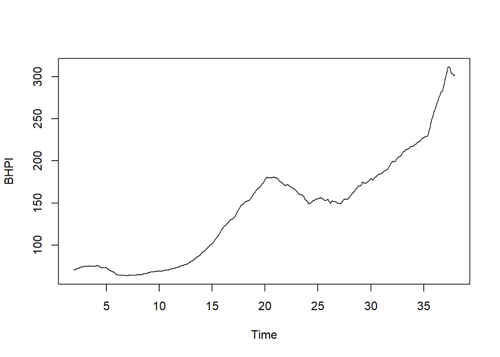

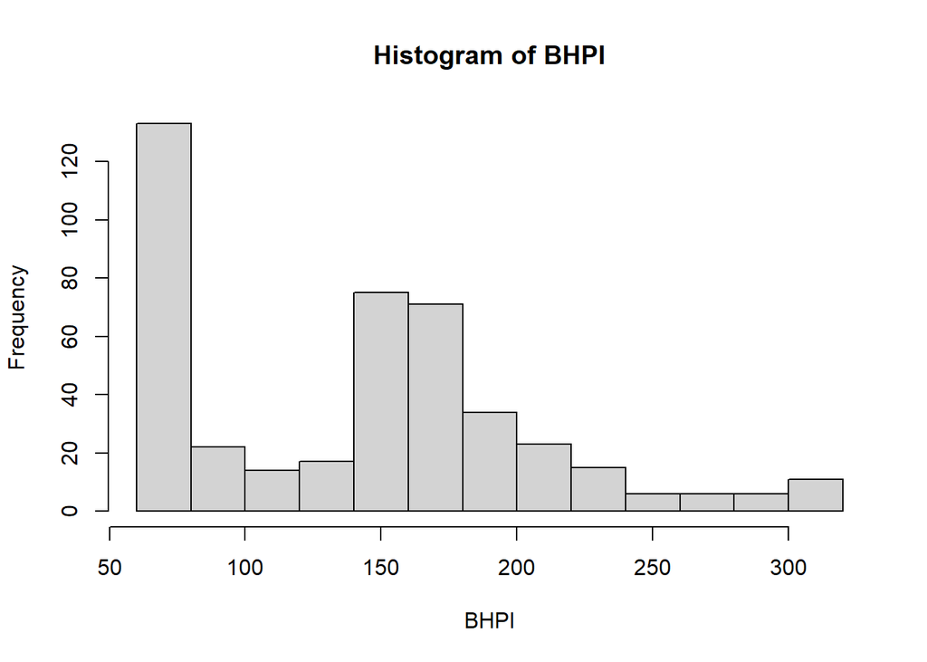

[output not shown]

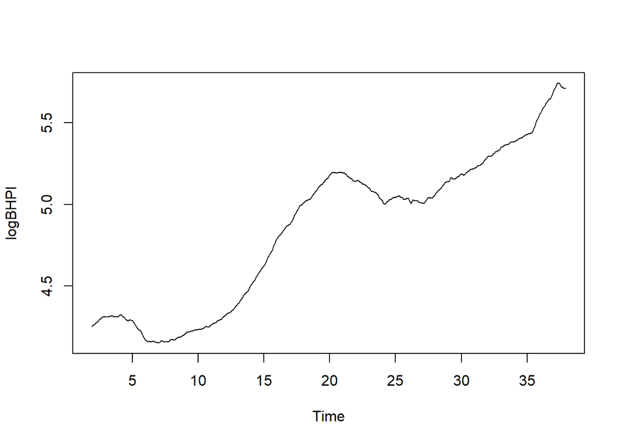

Summary statistics and the standard deviation of the growth rate are provided:

```
##       Min.    1st Qu.     Median       Mean    3rd Qu.       Max.
## -0.0166105 -0.0004284  0.0037021  0.0033801  0.0077389  0.0233282
```

```
## [1] 0.006572205
```

### Growth Rate Analysis

Summary statistics for the average growth rate of the Boston House Price Index is provided along with a histogram and density histogram analyzing the distribution of the Boston House Price Index:

```
##      Min.   1st Qu.    Median      Mean   3rd Qu.      Max.
## -0.182088 -0.005129  0.045340  0.044256  0.096923  0.318800
```

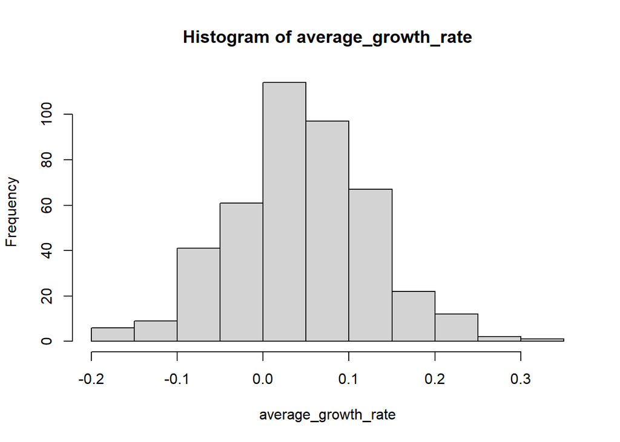

[output not shown]

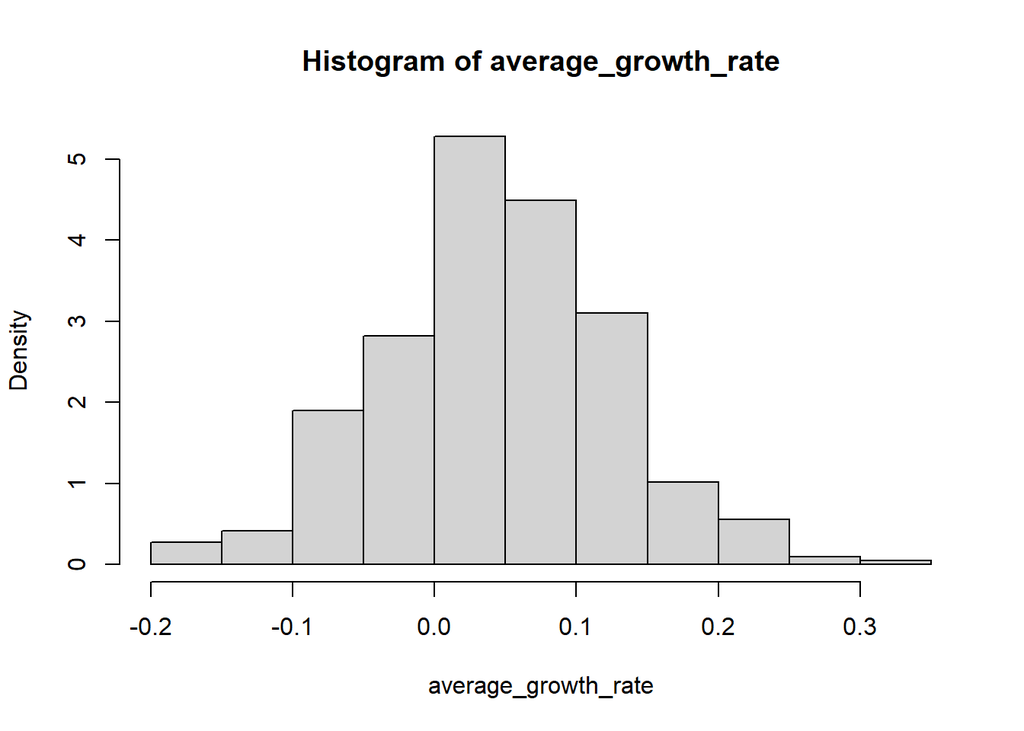

[output not shown]

Now, a 1-Sample t-Test must be conducted to determine whether the average growth rate is different from the value 0:

```r
t.test(average_growth_rate, mu = 0)
```

```
##
##  One Sample t-test
##
## data:  average_growth_rate
## t = 11.274, df = 431, p-value < 2.2e-16
## alternative hypothesis: true mean is not equal to 0
## 95 percent confidence interval:
##  0.03654085 0.05197151
## sample estimates:
##  mean of x
## 0.04425618
```

Observing the results from the 1-Sample t-Test, the p-value of $2.2e^{-16}$ suggests that at the 95% Confidence level, which will be the Confidence Level that is assumed going forward, that the average growth rate differs from 0.

### Predicting the Boston Housing Price Index (BHPI)

```
##
## Time series regression with "ts" data:
## Start = 1(12), End = 37(12)
##
## Call:
## dynlm(formula = BHPI ~ trend(BHPI))
##
## Residuals:
##     Min      1Q  Median      3Q     Max
## -33.928 -18.710  -5.347  17.751  71.407
##
## Coefficients:
##             Estimate Std. Error t value Pr(>|t|)
## (Intercept)  39.5997     2.1806   18.16   <2e-16 ***
## trend(BHPI)   5.6568     0.1045   54.14   <2e-16 ***
## ---
## Signif. codes:  0 '***' 0.001 '**' 0.01 '*' 0.05 '.' 0.1 ' ' 1
##
## Residual standard error: 22.65 on 431 degrees of freedom
## Multiple R-squared:  0.8718, Adjusted R-squared:  0.8715
## F-statistic:  2931 on 1 and 431 DF,  p-value: < 2.2e-16
```

The output above shows that the trend coefficient has a value of $5.6568$, meaning that for a one-year increase in the `trend(BHPI)` variable, on average, the BHPI increases by $5.6568$ points. The `trend(BHPI)` coefficient is statistically significant at the 5% significance level, since its p-value of $2.2e^{-16}$ is significantly less than the significance level $\alpha$ of 0.05. Its high test statistic of $54.14$ further corroborates the claim that `trend(BHPI)` is a statistically significant variable. It can be concluded from an overarching perspective that there is a long-term trend with the data.

A linear model attempting to fit this data is provided:

```
##
## Time series regression with "ts" data:
## Start = 1(12), End = 37(12)
##
## Call:
## dynlm(formula = logBHPI ~ trend(logBHPI))
##
## Residuals:
##      Min       1Q   Median       3Q      Max
## -0.21318 -0.11768 -0.05735  0.13813  0.33470
##
## Coefficients:
##                 Estimate Std. Error t value Pr(>|t|)
## (Intercept)    4.0840782  0.0148220  275.54   <2e-16 ***
## trend(logBHPI) 0.0423772  0.0007102   59.66   <2e-16 ***
## ---
## Signif. codes:  0 '***' 0.001 '**' 0.01 '*' 0.05 '.' 0.1 ' ' 1
##
## Residual standard error: 0.1539 on 431 degrees of freedom
## Multiple R-squared:  0.892,  Adjusted R-squared:  0.8918
## F-statistic:  3560 on 1 and 431 DF,  p-value: < 2.2e-16
```

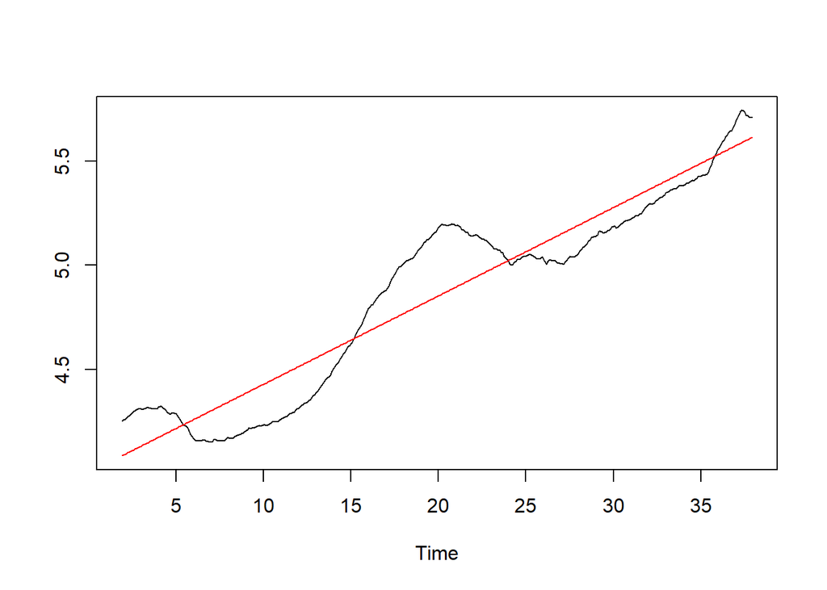

A Durbin-Watson Test shall now be performed on the model that utilizes the trend of the natural logarithm of BHPI to assess whether the true autocorrelation values are greater than $0$. The following hypotheses are tested:

$$\text{H}_{0}: \rho = 0
\\
\text{H}_{A}: \rho > 0$$

```
##
##  Durbin-Watson test
##
## data:  logmodel
## DW = 0.0018235, p-value < 2.2e-16
## alternative hypothesis: true autocorrelation is greater than 0
```

The output above shows that the p-value of $2.2𝑒^{−16}$ is once again significantly less than $\alpha$, which provides enough evidence to reject the Null Hypothesis and conclude that the true autocorrelation value is greater than 0 and that there appears to be autocorrelation among the residuals, which is a violation of one of the major assumption of regression. With this in mind, the analysis will carefully continue, keeping in mind that the residuals are highly correlated among each other.

Using a linear model to fit the growth and the trend found in the natural logarithm of BHPI is unreasonable here since the growth of this variable does not appear to be linear. The growth rate of the $\ln(BHPI)$ appears to be exponential, so a new exponential growth model will be used to determine this growth rate for the response variable `BHPI`:

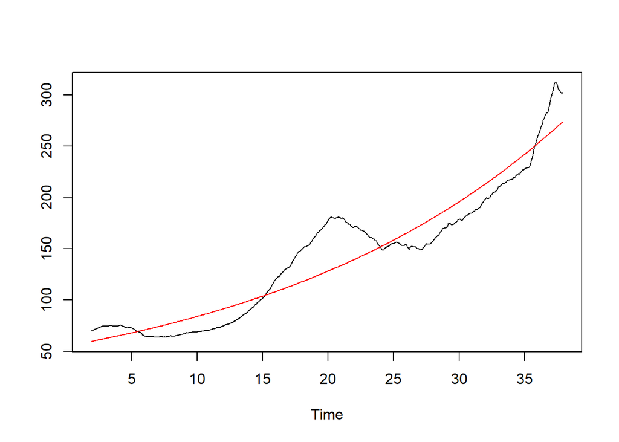

Although the exponential growth model that GrowthFit provides fits the data slightly better, it still remains a very rough estimate in an attempt to plot the average growth rate of $\ln(BHPI)$ over time while accounting for this trend. A more accurate exponential model must be constructed to better fit the data.

The process for selecting the appropriate Moving Average term consists of trial-and-error, and although tedious, a Moving Average Model of Order 50 appears to be the appropriate Moving Average term.

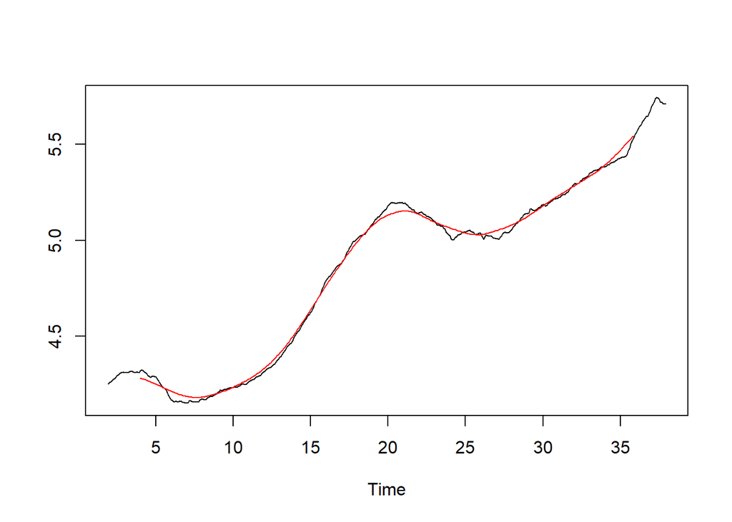

Suppose we wish to construct a Holt-Winters Filtering Model that predicts the `ln(BHPI)` trend better than the Moving Average Model of Order 50. We will see later in the report that a Moving Average of Order 50 is actually *not* as great of an estimate as it initially appears to be, so the **Holt-Winters Filtering Model** seeks to further improve the accuracy behind predicting the exponential growth that appears using $\ln(BHPI)$.

```
## Holt-Winters exponential smoothing without trend and without seasonal component.
##
## Call:
## HoltWinters(x = logBHPI, alpha = 0.15, beta = FALSE, gamma = FALSE)
##
## Smoothing parameters:
##  alpha: 0.15
##  beta : FALSE
##  gamma: FALSE
##
## Coefficients:
##       [,1]
## a 5.704227
```

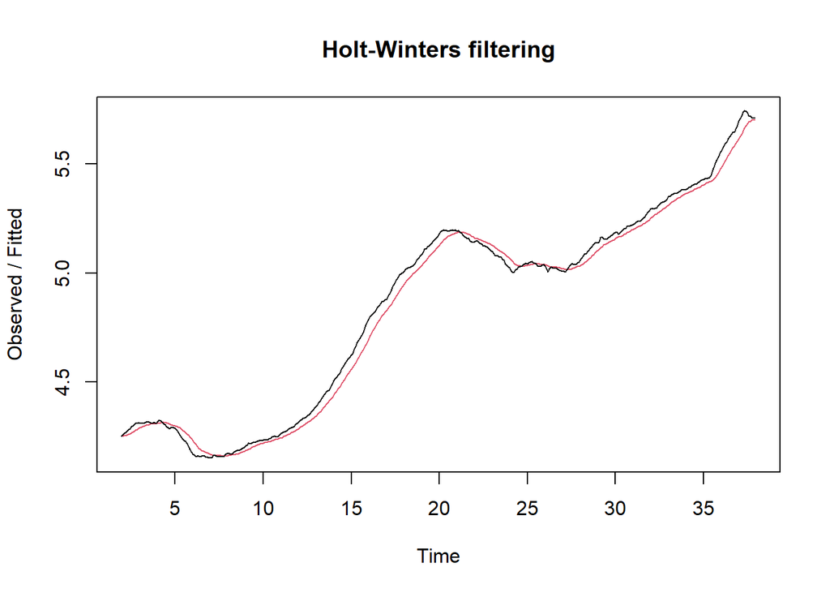

### Autocorrelation and Partial Autocorrelation Analysis

We now advance to analyzing the autocorrelation and Partial Autocorrelation functions of the first difference in the ln(BHPI).

Autocorrelation and Partial Autocorrelation plots are provided:

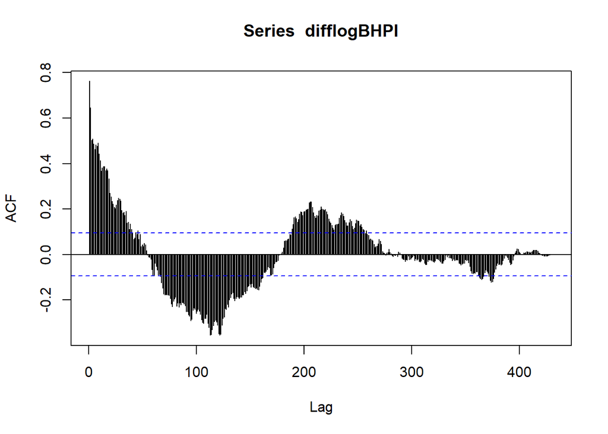

[output not shown]

[output cut: 28 more lines]

[output not shown]

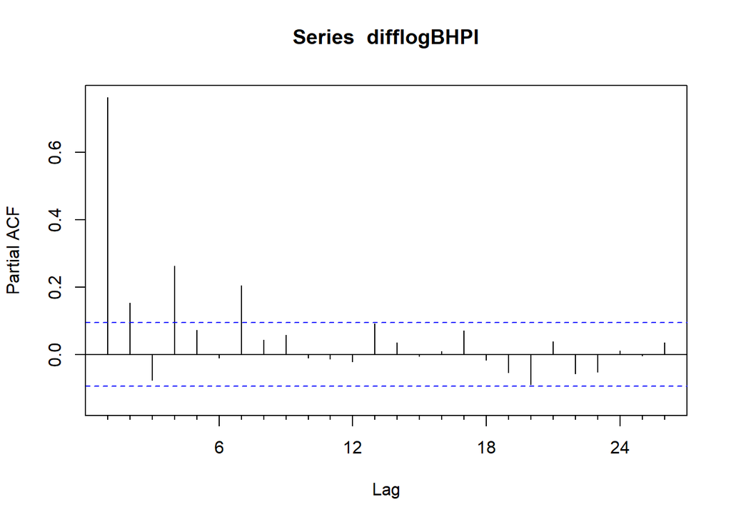

```
##
## Partial autocorrelations of series 'difflogBHPI', by lag
##
##      1      2      3      4      5      6      7      8      9     10     11
##  0.762  0.153 -0.077  0.262  0.072 -0.010  0.204  0.043  0.058 -0.011 -0.014
##     12     13     14     15     16     17     18     19     20     21     22
## -0.022  0.091  0.034 -0.005  0.010  0.071 -0.017 -0.053 -0.089  0.038 -0.057
##     23     24     25     26
## -0.053  0.012 -0.004  0.035
```

We wish to prove that the residuals are white noise, so in an unusual turn of events, we wish to prove the Null Hypothesis ${\text{(H}_{0})}$ correct:

```
##
##  Box-Ljung test
##
## data:  difflogBHPI
## X-squared = 1388.8, df = 12, p-value < 2.2e-16
```

The Ljung, or Chi-Squared test statistic ($\chi^{2}$) of $1388.8$ and a p-value of $2.2e^{-16}$ leads us to *reject* the Null Hypothesis ($\text{H}_{0}$) and conclude that the residuals are **not** White Noise, meaning the model we estimated thus far has been a poor estimation.

## Autoregressive Integrated Moving Avearge (ARIMA) Model Analysis

Another consideration to note is whether or not the data is *weakly stationary*. Three separate ARIMA models have been generated, named `Arima1`, `Arima2`, and `Arima3`. `Arima1` consists of the $8$ Autoregressive terms the Partial Autocorrelation plot suggested the model should incorporate, `Arima2` has the $8$ Autoregressive terms and $1$ Moving Average term, and `Arima3` consists of $8$ Autoregressive terms and $2$ Moving Average terms.

To determine whether or not these ARIMA models are weakly stationary, their plots must be provided:

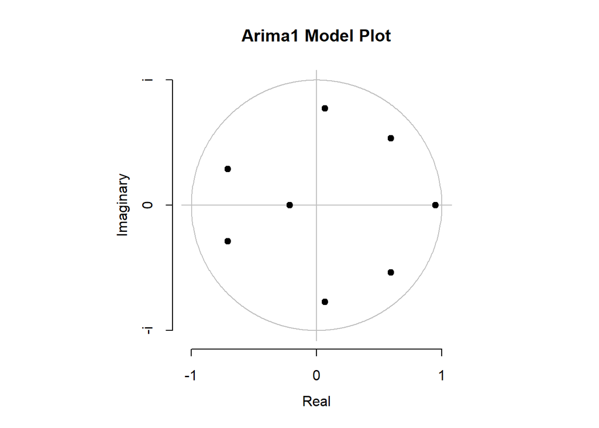

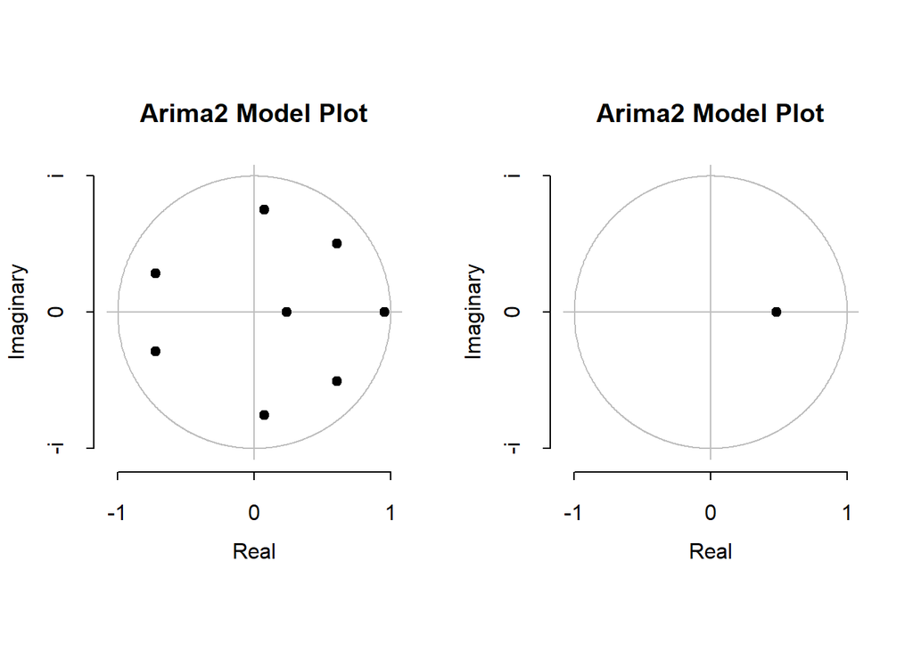

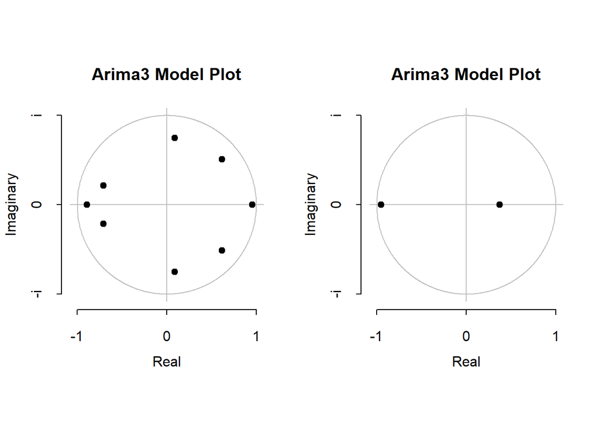

The plot for `Arima1` shows that the data is weakly stationary since all of the Autoregressive terms, represented by the black points, lie within the circle.

The plot for `Arima2` also shows that the data is weakly stationary since the Moving Average and Autoregressive terms, both represented by black points, lie within the circle.

Similar to `Arima1` and `Arima2`, the model `Arima3` is also weakly stationary, with its Moving Average and Autoregressive terms lying within their respective circles.

```
## Series: difflogBHPI
## ARIMA(8,0,0) with non-zero mean
##
## Coefficients:
##          ar1     ar2      ar3     ar4     ar5      ar6     ar7     ar8    mean
##       0.6493  0.1589  -0.3118  0.2587  0.0585  -0.1559  0.1822  0.0456  0.0033
## s.e.  0.0482  0.0568   0.0569  0.0589  0.0593   0.0573  0.0572  0.0486  0.0016
##
## sigma^2 = 1.579e-05:  log likelihood = 1778.91
## AIC=-3537.81   AICc=-3537.29   BIC=-3497.13
##
## Training set error measures:
##                         ME       RMSE         MAE       MPE     MAPE      MASE
## Training set -1.835443e-05 0.00393202 0.002939807 -64.74975 292.3533 0.5152073
##                      ACF1
## Training set -0.001129012
```

```
## Series: difflogBHPI
## ARIMA(8,0,1) with non-zero mean
##
## Coefficients:
##          ar1     ar2      ar3     ar4      ar5      ar6     ar7      ar8
##       1.1302  -0.158  -0.3855  0.4065  -0.0710  -0.1784  0.2494  -0.0494
## s.e.  0.6445   0.430   0.1199  0.2169   0.1956   0.0764  0.1300   0.1622
##           ma1    mean
##       -0.4835  0.0033
## s.e.   0.6401  0.0017
##
## sigma^2 = 1.58e-05:  log likelihood = 1779.22
## AIC=-3536.45   AICc=-3535.82   BIC=-3491.7
##
## Training set error measures:
##                         ME        RMSE         MAE      MPE     MAPE      MASE
## Training set -1.988837e-05 0.003929093 0.002938597 -67.4186 297.2136 0.5149952
##                     ACF1
## Training set 0.001990848
```

```
## Series: difflogBHPI
## ARIMA(8,0,2) with non-zero mean
##
## Coefficients:
##          ar1    ar2      ar3     ar4     ar5      ar6     ar7     ar8     ma1
##       0.0776  0.873  -0.4458  0.0245  0.3017  -0.2037  0.0718  0.1683  0.5755
## s.e.  0.2196  0.082   0.1661  0.0721  0.0675   0.0775  0.0518  0.0573  0.2206
##           ma2    mean
##       -0.3558  0.0033
## s.e.   0.1987  0.0017
##
## sigma^2 = 1.574e-05:  log likelihood = 1780.58
## AIC=-3537.16   AICc=-3536.41   BIC=-3488.34
##
## Training set error measures:
##                         ME       RMSE         MAE       MPE     MAPE      MASE
## Training set -1.894141e-05 0.00391629 0.002928931 -60.99449 284.7053 0.5133012
##                     ACF1
## Training set 0.001330551
```

A summary table for `Arima1`, `Arima2`, and `Arima3` regarding their measures is provided:

| Model | Autoregressive Terms | Moving Average Terms | Akaike Information Criteria (AIC) | Bayesian Information Criteria (BIC) |
| --- | --- | --- | --- | --- |
| `Arima1` | 8 | 0 | -3537.813132 | -3497.1288762 |
| `Arima2` | 8 | 1 | -3536.4481043 | -3491.6954228 |
| `Arima3` | 8 | 2 | -3537.157173 | -3488.3360659 |

Once the data is divided in the Training and Testing datasets, accurate forecasts can be produced. However, certain Hypothesis Tests must be conducted to ensure that the residuals sum to $0$ and are White Noise as well as to determine whether the value within the forecast of the ARIMA model are efficient.

The first test to perform is a t-Test evaluation of `Arima1`’s residuals and `Arima3`’s residuals to determine whether or not they sum to $0$. The following hypotheses are tested:

$$\text{H}_{0}: \text{Residuals} = 0
\\
\text{H}_{A}: \text{Residuals} \neq 0$$

```
##
##  One Sample t-test
##
## data:  Arima1$residuals
## t = -0.09691, df = 431, p-value = 0.9228
## alternative hypothesis: true mean is not equal to 0
## 95 percent confidence interval:
##  -0.0003906104  0.0003539015
## sample estimates:
##     mean of x
## -1.835443e-05
```

```
##
##  One Sample t-test
##
## data:  Arima3$residuals
## t = -0.10041, df = 431, p-value = 0.9201
## alternative hypothesis: true mean is not equal to 0
## 95 percent confidence interval:
##  -0.0003897079  0.0003518251
## sample estimates:
##     mean of x
## -1.894141e-05
```

Evaluating the results of these t-Tests for residuals of `Arima1` and `Arima3`, their p-values of $0.9228$ and $0.9201$, respectively, show that their respective residuals do indeed equal to $0$, which is what is desired for this test.

The second test to run before forecasting is the Box Test, which intends to analyze whether or not the residuals are White Noise. The following hypotheses are tested in the Box Test:

$$\text{H}_{0}: \text{Residuals are White Noise}
\\
\text{H}_{A}: \text{Residuals are NOT White Noise}$$

```r
Box.test(Arima1$residuals, 12, "Lj")
```

```
##
##  Box-Ljung test
##
## data:  Arima1$residuals
## X-squared = 3.5861, df = 12, p-value = 0.9898
```

```r
cat("\n\n\n")
```

```r
Box.test(Arima3$residuals, 12, "Lj")
```

```
##
##  Box-Ljung test
##
## data:  Arima3$residuals
## X-squared = 1.9263, df = 12, p-value = 0.9995
```

Analyzing the Box Test results of `Arima1`’s and `Arima3`’s residuals, their respective p-values of $0.9898$ and $0.9995$ show that their respective residuals are White Noise, which is what we want to conclude from this particular Hypothesis Test.

Now it is time to use the Test data for `Arima1` and `Arima3` to compare Model Performance:

```
## Series: difflogBHPI[Arima1TestingIndices]
## ARIMA(8,0,0) with non-zero mean
##
## Coefficients:
##          ar1      ar2      ar3     ar4      ar5      ar6     ar7      ar8
##       0.0067  -0.1677  -0.7242  0.0317  -0.5415  -0.2126  0.0277  -0.4697
## s.e.  0.1571   0.1559   0.1605  0.1988   0.1863   0.1646  0.1681   0.1602
##         mean
##       0.0028
## s.e.  0.0004
##
## sigma^2 = 3.351e-05:  log likelihood = 115.58
## AIC=-211.15   AICc=-199.57   BIC=-197.14
##
## Training set error measures:
##                        ME        RMSE         MAE      MPE     MAPE      MASE
## Training set 8.632941e-06 0.004843242 0.003670344 65.04999 86.98691 0.4696429
##                    ACF1
## Training set 0.01532569
```

```
## Series: difflogBHPI[Arima3TestingIndices]
## ARIMA(8,0,2) with non-zero mean
##
## Coefficients:
##           ar1     ar2     ar3      ar4      ar5     ar6     ar7      ar8
##       -0.2761  0.1772  0.1838  -0.1423  -0.0490  0.3088  0.0540  -0.3844
## s.e.   0.4969  0.3796  0.2072   0.2480   0.1677  0.2202  0.1996   0.2252
##          ma1     ma2    mean
##       0.3151  0.2412  0.0043
## s.e.  0.5653  0.4047  0.0011
##
## sigma^2 = 3.344e-05:  log likelihood = 143.36
## AIC=-262.72   AICc=-249.72   BIC=-243.39
##
## Training set error measures:
##                         ME       RMSE         MAE       MPE     MAPE      MASE
## Training set -3.785142e-05 0.00484768 0.004155605 -73.18901 191.8174 0.5660132
##                      ACF1
## Training set -0.005115832
```

Given these outputs, we find that the RMSE values of `Arima1` and `Arima3` using the Testing datasets are approximately $0.00484$ and $0.00485$, respectively, and their respective MAE values are approximately $0.00367$ and $0.00416$.

The Efficiency Test must now be performed on the `Arima1` and `Arima3` models to effectively determine whether the parameters `Arima1$fitted` or `Arima3$fitted` fitted values sum to $0$ and are therefore efficient. The hypotheses to consider for this particular test are:

$$\text{H}_{0}: \text{The Fitted Values for `Arima1`/`Arima3` is
Efficient}
\\
\text{H}_{A}: \text{The Fitted Values for `Arima1`/`Arima3` is NOT
Efficient}$$

```r
EfficiencyTest1 <- lm(Arima1$residuals~Arima1$fitted)
EfficiencyTest2 <- lm(Arima3$residuals~Arima3$fitted)

summary(EfficiencyTest1)
```

```
##
## Call:
## lm(formula = Arima1$residuals ~ Arima1$fitted)
##
## Residuals:
##        Min         1Q     Median         3Q        Max
## -0.0157339 -0.0021815 -0.0000562  0.0022707  0.0216121
##
## Coefficients:
##                 Estimate Std. Error t value Pr(>|t|)
## (Intercept)   -3.156e-05  2.260e-04  -0.140    0.889
## Arima1$fitted  3.884e-03  3.621e-02   0.107    0.915
##
## Residual standard error: 0.003941 on 430 degrees of freedom
## Multiple R-squared:  2.676e-05,  Adjusted R-squared:  -0.002299
## F-statistic: 0.01151 on 1 and 430 DF,  p-value: 0.9146
```

```r
cat("\n\n\n")
```

```r
summary(EfficiencyTest2)
```

```
##
## Call:
## lm(formula = Arima3$residuals ~ Arima3$fitted)
##
## Residuals:
##        Min         1Q     Median         3Q        Max
## -0.0158173 -0.0022181 -0.0000326  0.0023333  0.0214817
##
## Coefficients:
##                 Estimate Std. Error t value Pr(>|t|)
## (Intercept)   -3.353e-05  2.250e-04  -0.149    0.882
## Arima3$fitted  4.292e-03  3.600e-02   0.119    0.905
##
## Residual standard error: 0.003925 on 430 degrees of freedom
## Multiple R-squared:  3.306e-05,  Adjusted R-squared:  -0.002292
## F-statistic: 0.01422 on 1 and 430 DF,  p-value: 0.9052
```

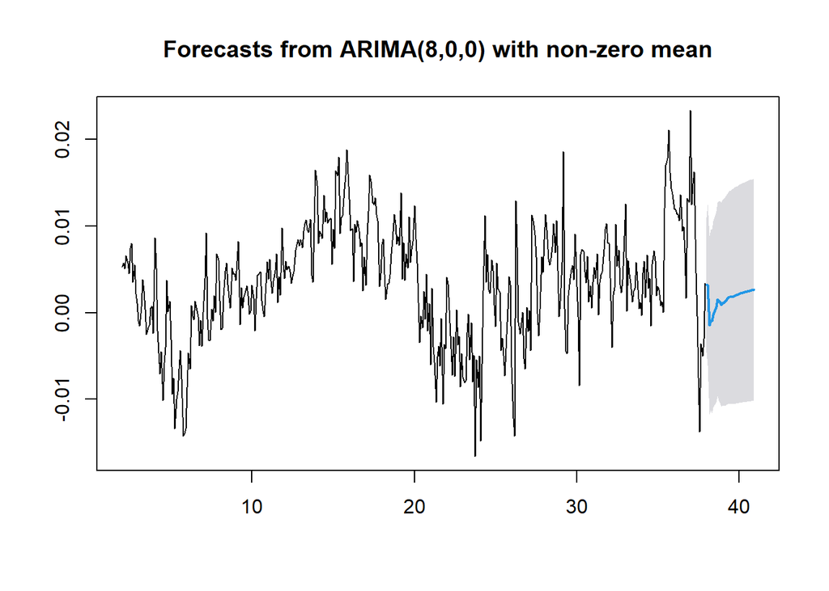

```r
Forecast1 <- forecast(Arima1, 36, 95)
plot(Forecast1)
```

```r
print(Forecast1)
```

```
##        Point Forecast        Lo 95       Hi 95
## Jan 38   0.0032139745 -0.004574196 0.011002145
## Feb 38   0.0031955706 -0.006090259 0.012481401
## Mar 38  -0.0014453746 -0.011773146 0.008882396
## Apr 38  -0.0008670294 -0.011277628 0.009543569
## May 38  -0.0009889549 -0.011591371 0.009613461
## Jun 38  -0.0002362169 -0.011001680 0.010529246
## Jul 38   0.0001271807 -0.010725612 0.010979973
## Aug 38   0.0006645931 -0.010336021 0.011665208
## Sep 38   0.0015518545 -0.009624084 0.012727793
## Oct 38   0.0013510827 -0.010120620 0.012822786
## Nov 38   0.0012447446 -0.010405249 0.012894738
## Dec 38   0.0009143729 -0.010873078 0.012701823
## Jan 39   0.0010815131 -0.010802776 0.012965802
## Feb 39   0.0011874995 -0.010788056 0.013163055
## Mar 39   0.0013228246 -0.010734143 0.013379792
## Apr 39   0.0015012081 -0.010624763 0.013627179
## May 39   0.0016498897 -0.010550206 0.013849985
## Jun 39   0.0017927319 -0.010478540 0.014064004
## Jul 39   0.0018036042 -0.010536286 0.014143495
## Aug 39   0.0018399304 -0.010556127 0.014235987
## Sep 39   0.0018754689 -0.010569593 0.014320531
## Oct 39   0.0019482759 -0.010540119 0.014436670
## Nov 39   0.0020165494 -0.010510717 0.014543816
## Dec 39   0.0020843715 -0.010478142 0.014646885
## Jan 40   0.0021589959 -0.010435492 0.014753483
## Feb 40   0.0022206956 -0.010403882 0.014845273
## Mar 40   0.0022749696 -0.010377061 0.014927000
## Apr 40   0.0023150760 -0.010361813 0.014991965
## May 40   0.0023580275 -0.010340976 0.015057031
## Jun 40   0.0024008902 -0.010318013 0.015119793
## Jul 40   0.0024445372 -0.010292343 0.015181417
## Aug 40   0.0024869255 -0.010266190 0.015240041
## Sep 40   0.0025276685 -0.010240196 0.015295533
## Oct 40   0.0025673076 -0.010213969 0.015348584
## Nov 40   0.0026031948 -0.010190321 0.015396711
## Dec 40   0.0026365892 -0.010168021 0.015441199
```

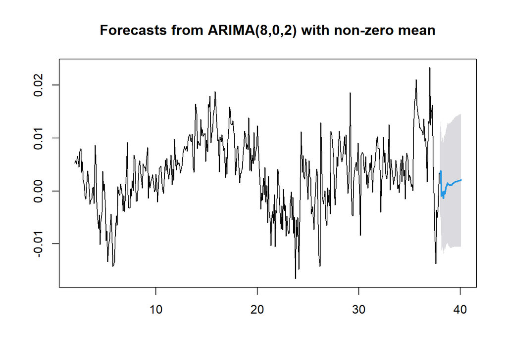

```r
Forecast2 <- forecast(Arima3, 26, 95)
plot(Forecast2)
```

```r
print(Forecast2)
```

```
##        Point Forecast        Lo 95       Hi 95
## Jan 38   3.330347e-03 -0.004445070 0.011105765
## Feb 38   3.827238e-03 -0.005459425 0.013113901
## Mar 38  -9.563472e-04 -0.011239174 0.009326479
## Apr 38  -1.635103e-04 -0.010529321 0.010202300
## May 38  -1.372869e-03 -0.011908303 0.009162565
## Jun 38  -2.870412e-05 -0.010715294 0.010657886
## Jul 38  -5.004530e-04 -0.011260595 0.010259689
## Aug 38   7.200994e-04 -0.010175049 0.011615247
## Sep 38   1.016962e-03 -0.010001721 0.012035645
## Oct 38   1.562630e-03 -0.009753434 0.012878693
## Nov 38   1.212308e-03 -0.010261923 0.012686539
## Dec 38   1.189574e-03 -0.010470796 0.012849945
## Jan 39   1.003364e-03 -0.010742589 0.012749316
## Feb 39   1.171927e-03 -0.010693261 0.013037116
## Mar 39   1.136413e-03 -0.010795885 0.013068711
## Apr 39   1.373114e-03 -0.010645342 0.013391570
## May 39   1.434366e-03 -0.010644113 0.013512846
## Jun 39   1.680832e-03 -0.010478449 0.013840112
## Jul 39   1.675234e-03 -0.010546652 0.013897120
## Aug 39   1.806220e-03 -0.010485347 0.014097786
## Sep 39   1.762540e-03 -0.010579965 0.014105045
## Oct 39   1.878128e-03 -0.010518275 0.014274531
## Nov 39   1.863337e-03 -0.010573996 0.014300670
## Dec 39   1.978121e-03 -0.010502180 0.014458422
## Jan 40   1.990172e-03 -0.010523891 0.014504235
## Feb 40   2.101952e-03 -0.010448072 0.014651976
```

Note that the forecasted values are extremely similar between `Arima1` and `Arima3`; the only difference between them is the additional $2$ Moving Average terms found in `Arima3`, and it seems to have very little impact on the forecasted values.

Examining the mean, lower, and upper forecasted values for both `Arima1` and `Arima3` at the 95% Confidence Level, the black curve represents the time-series plot of the mean 95% Confidence values for the models, the blue curve represents the time-series plot of the lower 95% Confidence values for the model, and the represents the time-series plot of the upper 95% Confidence values for the model:

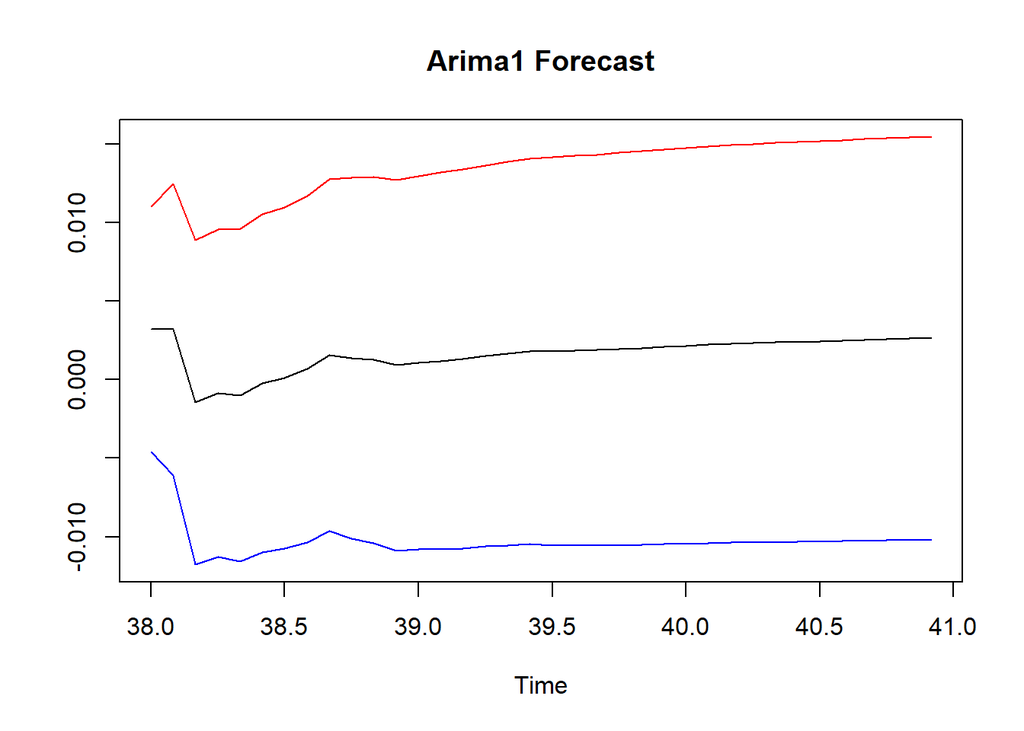

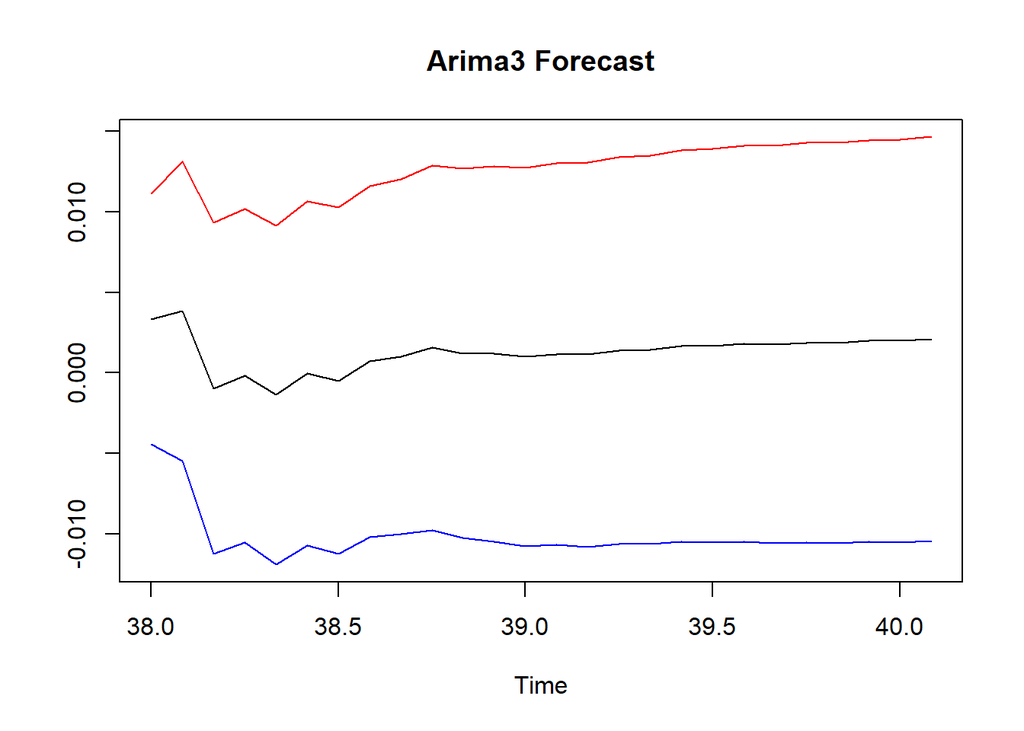

```
##            X95. Forecast1.mean      X95..1
## 1  -0.004574196   0.0032139745 0.011002145
## 2  -0.006090259   0.0031955706 0.012481401
## 3  -0.011773146  -0.0014453746 0.008882396
## 4  -0.011277628  -0.0008670294 0.009543569
## 5  -0.011591371  -0.0009889549 0.009613461
## 6  -0.011001680  -0.0002362169 0.010529246
## 7  -0.010725612   0.0001271807 0.010979973
## 8  -0.010336021   0.0006645931 0.011665208
## 9  -0.009624084   0.0015518545 0.012727793
## 10 -0.010120620   0.0013510827 0.012822786
## 11 -0.010405249   0.0012447446 0.012894738
## 12 -0.010873078   0.0009143729 0.012701823
## 13 -0.010802776   0.0010815131 0.012965802
## 14 -0.010788056   0.0011874995 0.013163055
```

[output cut: 22 more lines]

```
##            X95. Forecast2.mean      X95..1
## 1  -0.004445070   3.330347e-03 0.011105765
## 2  -0.005459425   3.827238e-03 0.013113901
## 3  -0.011239174  -9.563472e-04 0.009326479
## 4  -0.010529321  -1.635103e-04 0.010202300
## 5  -0.011908303  -1.372869e-03 0.009162565
## 6  -0.010715294  -2.870412e-05 0.010657886
## 7  -0.011260595  -5.004530e-04 0.010259689
## 8  -0.010175049   7.200994e-04 0.011615247
## 9  -0.010001721   1.016962e-03 0.012035645
## 10 -0.009753434   1.562630e-03 0.012878693
## 11 -0.010261923   1.212308e-03 0.012686539
## 12 -0.010470796   1.189574e-03 0.012849945
## 13 -0.010742589   1.003364e-03 0.012749316
## 14 -0.010693261   1.171927e-03 0.013037116
## 15 -0.010795885   1.136413e-03 0.013068711
## 16 -0.010645342   1.373114e-03 0.013391570
## 17 -0.010644113   1.434366e-03 0.013512846
## 18 -0.010478449   1.680832e-03 0.013840112
## 19 -0.010546652   1.675234e-03 0.013897120
## 20 -0.010485347   1.806220e-03 0.014097786
## 21 -0.010579965   1.762540e-03 0.014105045
## 22 -0.010518275   1.878128e-03 0.014274531
## 23 -0.010573996   1.863337e-03 0.014300670
## 24 -0.010502180   1.978121e-03 0.014458422
## 25 -0.010523891   1.990172e-03 0.014504235
## 26 -0.010448072   2.101952e-03 0.014651976
```

Another Hypothesis Tests to run for Model3 is the Coefficient Test, which is a Hypothesis Test that seeks to determine which Autoregressive and/or Moving Average components of a model are statistically significant coefficients. Running the Coefficient Test in R for `Arima1` and `Arima3` yields the following:

```
##
## z test of coefficients:
##
##             Estimate Std. Error z value  Pr(>|z|)
## ar1        0.6492899  0.0481686 13.4795 < 2.2e-16 ***
## ar2        0.1588725  0.0568251  2.7958  0.005177 **
## ar3       -0.3117521  0.0569016 -5.4788 4.282e-08 ***
## ar4        0.2587179  0.0589388  4.3896 1.136e-05 ***
## ar5        0.0585260  0.0592921  0.9871  0.323604
## ar6       -0.1558532  0.0572823 -2.7208  0.006513 **
## ar7        0.1822012  0.0572288  3.1837  0.001454 **
## ar8        0.0456482  0.0485994  0.9393  0.347590
## intercept  0.0033134  0.0015905  2.0832  0.037231 *
## ---
## Signif. codes:  0 '***' 0.001 '**' 0.01 '*' 0.05 '.' 0.1 ' ' 1
```

```
##
## z test of coefficients:
##
##             Estimate Std. Error z value  Pr(>|z|)
## ar1        0.0775695  0.2195612  0.3533  0.723869
## ar2        0.8729813  0.0820358 10.6415 < 2.2e-16 ***
## ar3       -0.4458129  0.1660873 -2.6842  0.007270 **
## ar4        0.0245295  0.0720774  0.3403  0.733614
## ar5        0.3017281  0.0675327  4.4679   7.9e-06 ***
## ar6       -0.2036645  0.0774963 -2.6281  0.008587 **
## ar7        0.0717870  0.0517569  1.3870  0.165441
## ar8        0.1682598  0.0573157  2.9357  0.003328 **
## ma1        0.5755006  0.2206178  2.6086  0.009092 **
## ma2       -0.3557927  0.1986685 -1.7909  0.073312 .
## intercept  0.0033050  0.0016577  1.9937  0.046183 *
## ---
## Signif. codes:  0 '***' 0.001 '**' 0.01 '*' 0.05 '.' 0.1 ' ' 1
```

For `Arima1` at the $0.05$ Significance Level ($\alpha = 0.05$), the `ar1`, `ar2`, `ar3`, `ar4`, `ar6`, and `ar7` Autoregressive Terms are all statistically significant coefficients since their individual p-values are less than $\alpha$. The `ar5` and `ar8` Autoregressive Terms, however, are *not* statistically significant coefficients for the `Arima1` model at the $0.05$ Significance Level. This suggests that for this model, `Arima1` should be updated to include only $6$ Autoregressive Terms.

Suppose we want to construct another ARIMA model, `Arima4`, but uses the command `auto.arima()` to allow $R$ to automatically determine the best ARIMA Model components, specifically the number of Autoregressive and Moving Average Terms. In addition, the **Akaike Information Criteria (AIC)** value will be the Information Criteria that $R$ will have to optimize on in the construction of this model. How does it perform?

```
## Series: logBHPI
## ARIMA(0,2,4)(0,0,1)[12]
##
## Coefficients:
##           ma1      ma2      ma3     ma4     sma1
##       -0.3379  -0.0655  -0.4058  0.0946  -0.1128
## s.e.   0.0480   0.0472   0.0477  0.0487   0.0542
##
## sigma^2 = 1.598e-05:  log likelihood = 1771.56
## AIC=-3531.12   AICc=-3530.93   BIC=-3506.73
##
## Training set error measures:
##                        ME        RMSE         MAE           MPE       MAPE
## Training set -3.26495e-05 0.003965426 0.002916031 -0.0003467079 0.05963303
##                    MASE         ACF1
## Training set 0.04746526 -0.004302158
```

The best ARIMA model $R$ has generated given that AIC is fully optimized includes $0$ Autoregresive Terms, $2$ *Degrees of Differencing*, and $4$ Moving Average Terms. The AIC of `Arima4` is $-3531.12$, the BIC value is $-3506.73$, the RMSE is approximately $0.004$, and the *Mean Absolute Value (MAE)* is $0.0029$.

With `auto.arima` in `Arima4`, **Backward Stepwise Procedures** to produce the best model and **Seasonal Adjustments** were taken into consideration by default. What if these aspects were *not* considered? `Arima5` explores this possibility:

```
## Series: logBHPI
## ARIMA(0,2,4)
##
## Coefficients:
##           ma1      ma2      ma3     ma4
##       -0.3335  -0.0723  -0.4232  0.1016
## s.e.   0.0477   0.0463   0.0480  0.0492
##
## sigma^2 = 1.611e-05:  log likelihood = 1769.41
## AIC=-3528.82   AICc=-3528.68   BIC=-3508.49
##
## Training set error measures:
##                         ME       RMSE         MAE           MPE       MAPE
## Training set -3.863035e-05 0.00398574 0.002950929 -0.0004627623 0.06033971
##                   MASE         ACF1
## Training set 0.0480333 -0.005210632
```

Similar to `Arima4`, `Arima5` using `auto.arima()` and specifying the `stepwise` and `seasonal` parameters to `FALSE` includes $0$ Autoregresive Terms, $2$ *Degrees of Differencing*, and $4$ Moving Average Terms. This suggests that the data is *not* seasonal over this timeframe (January 1987 - January 2023).

Running Box Tests on `Arima4` and `Arima5` tests whether or not their residuals are White Noise:

$$\text{H}_{0}: \text{Residuals are White Noise}
\\
\text{H}_{A}: \text{Residuals are NOT White Noise}$$

```r
Box.test(Arima4$residuals, 12, "Lj", 5)
```

```
##
##  Box-Ljung test
##
## data:  Arima4$residuals
## X-squared = 4.5125, df = 7, p-value = 0.7192
```

```r
cat("\n\n\n")
```

```r
Box.test(Arima5$residuals, 12, "Lj", 5)
```

```
##
##  Box-Ljung test
##
## data:  Arima5$residuals
## X-squared = 8.1474, df = 7, p-value = 0.3198
```

```
##
## z test of coefficients:
##
##       Estimate Std. Error z value  Pr(>|z|)
## ma1  -0.337850   0.048010 -7.0370 1.964e-12 ***
## ma2  -0.065510   0.047229 -1.3871   0.16542
## ma3  -0.405848   0.047713 -8.5060 < 2.2e-16 ***
## ma4   0.094613   0.048693  1.9430   0.05201 .
## sma1 -0.112838   0.054248 -2.0800   0.03752 *
## ---
## Signif. codes:  0 '***' 0.001 '**' 0.01 '*' 0.05 '.' 0.1 ' ' 1
```

```
##
## z test of coefficients:
##
##      Estimate Std. Error z value  Pr(>|z|)
## ma1 -0.333474   0.047678 -6.9943 2.666e-12 ***
## ma2 -0.072279   0.046299 -1.5611   0.11849
## ma3 -0.423193   0.048006 -8.8153 < 2.2e-16 ***
## ma4  0.101570   0.049162  2.0660   0.03882 *
## ---
## Signif. codes:  0 '***' 0.001 '**' 0.01 '*' 0.05 '.' 0.1 ' ' 1
```

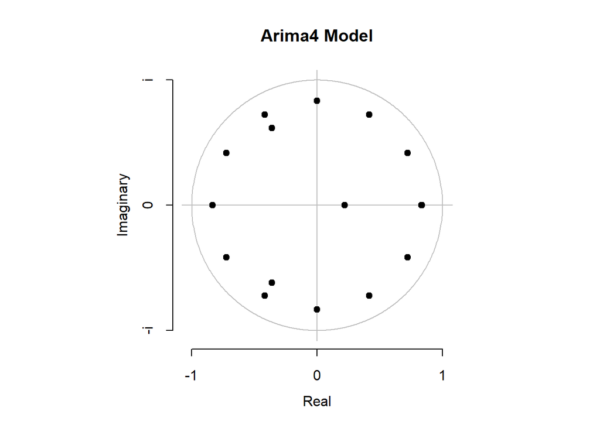

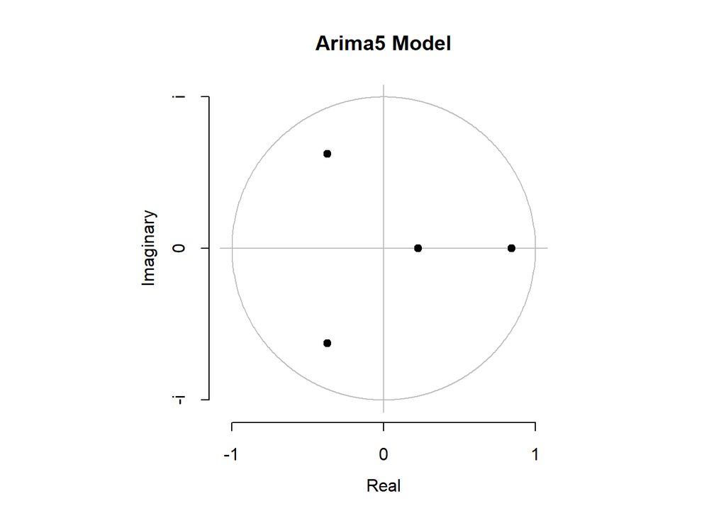

The statistically significant terms at the 5% Significance Level ($\alpha = 0.05$) for `Arima4` and `Arima5` are `ma1`, `ma3`, and `sma1`. The statistically significant terms at the 5% Significance Level ($\alpha = 0.05$) for `Arima5` are `ma1`, `ma3`, and `ma4`. This further corroborates the claim that `auto.arima()` did *not* produce the most optimized ARIMA model possible.

The plots of `Arima4` and `Arima5` show that all terms in the model are weakly stationary, as all black dots lie within the circle.

### Model Evaluation

#### `Arima1` Model Evaluation

With the Training and Test datasets already completed in a previous step, now it is time to apply a forecast to the trained `Arima1` model:

```
## Series: Arima1TrainingIndices
## ARIMA(8,0,0) with non-zero mean
##
## Coefficients:
##          ar1      ar2      ar3     ar4      ar5     ar6      ar7     ar8
##       0.2935  -0.1292  -0.1657  0.2319  -0.4306  0.1069  -0.0587  0.2319
## s.e.  0.1823   0.1898   0.1974  0.1795   0.1882  0.2133   0.2264  0.2110
##           mean
##       193.8922
## s.e.   17.0642
##
## sigma^2 = 9102:  log likelihood = -175.11
## AIC=370.22   AICc=381.8   BIC=384.23
##
## Training set error measures:
##                    ME     RMSE      MAE       MPE     MAPE      MASE       ACF1
## Training set 1.033445 79.82171 66.42929 -33.99568 57.22896 0.5254908 0.03670573
```

```
## Series: Arima1TestingIndices
## ARIMA(8,0,0) with non-zero mean
##
## Coefficients:
##          ar1     ar2      ar3     ar4     ar5      ar6     ar7     ar8    mean
##       0.6493  0.1589  -0.3118  0.2587  0.0585  -0.1559  0.1822  0.0456  0.0033
## s.e.  0.0000  0.0000   0.0000  0.0000  0.0000   0.0000  0.0000  0.0000  0.0000
##
## sigma^2 = 1.579e-05:  log likelihood = -186.34
## AIC=374.69   AICc=374.83   BIC=376.09
##
## Training set error measures:
##                    ME     RMSE      MAE       MPE     MAPE     MASE       ACF1
## Training set 29.38644 117.4765 102.6596 -12.74574 65.28702 0.812092 -0.2999133
```

The results are in, and they aren’t looking so hot…$AIC$ and $BIC$ values are positive, where they should be negative. MAE will be artificially higher due to the smaller sample size being analyzed, but RMSE values are large also.

Are the mean of the residuals equivalent to 0?

```
##
##  One Sample t-test
##
## data:  Model1Forecast$residuals
## t = 1.3913, df = 29, p-value = 0.1747
## alternative hypothesis: true mean is not equal to 0
## 95 percent confidence interval:
##  -13.81145  72.58433
## sample estimates:
## mean of x
##  29.38644
```

With a p-value of $0.1747$, it is greater than the Significance Level $\alpha$ ($0.05$), leading us to conclude that the Null Hypothesis *cannot* be rejected, showing that the true mean of the residuals is equivalent to $0$. This is promising, but still needs some fine-tuning.

The Box Test will confirm whether or not the residuals are White Noise:

```
##
##  Box-Ljung test
##
## data:  Model1Forecast$residuals
## X-squared = 25.069, df = 12, p-value = 0.0145
```

An Efficiency Test is required now. It should be noted that these conclusions about the Model thus far are due to the very small sample size in `Model1Forecast`. An **Efficiency Test** takes a dependent variable ($y$), in this case the residuals of `Model1Forecast`, and an independent variable ($x$), in this case the fitted values of `Model1Forecast`, to determine if the residuals can be predicted by the fitted values (i.e. can $y$ be predicted by $x$).

```
##
## Call:
## lm(formula = Model1Forecast$residuals ~ Model1Forecast$fitted)
##
## Residuals:
##      Min       1Q   Median       3Q      Max
## -141.204  -88.793   -4.518   89.471  197.137
##
## Coefficients:
##                       Estimate Std. Error t value Pr(>|t|)
## (Intercept)           146.5337    45.6866   3.207  0.00334 **
## Model1Forecast$fitted  -0.7056     0.2503  -2.819  0.00875 **
## ---
## Signif. codes:  0 '***' 0.001 '**' 0.01 '*' 0.05 '.' 0.1 ' ' 1
##
## Residual standard error: 103.9 on 28 degrees of freedom
## Multiple R-squared:  0.221,  Adjusted R-squared:  0.1932
## F-statistic: 7.945 on 1 and 28 DF,  p-value: 0.008752
```

The predictor `Model1Forecast$fitted` has a p-value of $0.00875$, which is less than the specified Signifance Level ($\alpha$) of $0.05$, thereby suggesting to reject the Null Hypothesis ($\text{H}_0$) and conclude that the predictor `Model1Forecast$fitted` is a statistically significant predictor in predicting `Model1Forecast`’s residuals.

A **Linear Hypothesis Test** (`lht`) must be performed on `Model1Forecast$fitted` to determine if a *Restricted Model* is better in predicting the residuals in `Model1Forecast` than the model that uses the `Model1Forecast$fitted` predictor. The following hypotheses are tested:

$$\text{H}_{0}: \text{Restricted Model Predicts Residuals in
`Model1Forecast` Better than Full Model}
\\
\text{H}_{A}: \text{Restricted Model DOES NOT Predict Residuals in
`Model1Forecast` Better than Full Model}$$

```r
lht(EfficiencyModel1, "(Intercept)=Model1Forecast$fitted")
```

```
## Linear hypothesis test
##
## Hypothesis:
## (Intercept) - Model1Forecast$fitted = 0
##
## Model 1: restricted model
## Model 2: Model1Forecast$residuals ~ Model1Forecast$fitted
##
##   Res.Df    RSS Df Sum of Sq      F   Pr(>F)
## 1     29 413369
## 2     28 302331  1    111038 10.284 0.003347 **
## ---
## Signif. codes:  0 '***' 0.001 '**' 0.01 '*' 0.05 '.' 0.1 ' ' 1
```

With a p-value of $0.003347$, this is less than the Significance Level $\alpha$ ($0.05$), which allows us to reject the Null Hypothesis ($\text{H}_{0}$) and conclude that the `Model1Forecast$fitted` predictor predicts the residuals better.

#### `Arima3` Model Evaluation

Now `Arima3` will be used to forecast and predict just like `Arima1`. The Training and Test data are already defined.

```
## Series: Arima3TrainingIndices
## ARIMA(8,0,2) with non-zero mean
##
## Coefficients:
##           ar1     ar2      ar3     ar4      ar5      ar6      ar7     ar8
##       -0.2857  0.0376  -0.2218  0.0705  -0.2514  -0.1801  -0.0376  0.2356
## s.e.   0.6679  0.4407   0.2198  0.2732   0.2386   0.3280   0.3322  0.2414
##          ma1     ma2      mean
##       0.6429  0.0024  192.6649
## s.e.  0.6857  0.5684   15.8897
##
## sigma^2 = 9644:  log likelihood = -174.72
## AIC=373.44   AICc=391.79   BIC=390.25
##
## Training set error measures:
##                    ME     RMSE      MAE       MPE    MAPE      MASE        ACF1
## Training set 1.296991 78.15098 65.24388 -33.85109 55.7106 0.5161136 0.002459157
```

```
## Series: Arima3TestingIndices
## ARIMA(8,0,2) with non-zero mean
##
## Coefficients:
##          ar1    ar2      ar3     ar4     ar5      ar6     ar7     ar8     ma1
##       0.0776  0.873  -0.4458  0.0245  0.3017  -0.2037  0.0718  0.1683  0.5755
## s.e.  0.0000  0.000   0.0000  0.0000  0.0000   0.0000  0.0000  0.0000  0.0000
##           ma2    mean
##       -0.3558  0.0033
## s.e.   0.0000  0.0000
##
## sigma^2 = 1.574e-05:  log likelihood = -235.56
## AIC=473.11   AICc=473.23   BIC=474.72
##
## Training set error measures:
##                    ME     RMSE      MAE       MPE     MAPE      MASE       ACF1
## Training set 27.11303 137.6281 111.9715 -94.40955 157.4236 0.8513148 -0.4956977
```

The results are in, and they aren’t looking so hot, either…$AIC$ and $BIC$ values are positive, where they should be negative. MAE will be artificially higher due to the smaller sample size being analyzed, but RMSE values are large also. In fact, this did slightly *worse* than the `Model1Forecast`. Yikes.

Are the mean of the residuals here equivalent to 0?

```
##
##  One Sample t-test
##
## data:  Model3Forecast$residuals
## t = 1.2056, df = 36, p-value = 0.2358
## alternative hypothesis: true mean is not equal to 0
## 95 percent confidence interval:
##  -18.49575  72.72181
## sample estimates:
## mean of x
##  27.11303
```

With a p-value of 0.2358, this is significantly greater than the Significance Level $\alpha$ ($0.05$), so the Null Hypothesis **cannot** be rejected and it can be concluded that the true mean of the residuals is equivalent to 0. That’s a good sign, at least.

Are the residuals White Noise, though?

```
##
##  Box-Ljung test
##
## data:  Model3Forecast$residuals
## X-squared = 24.556, df = 12, p-value = 0.01707
```

The p-value of $0.01707$ is less than the Significance Level $\alpha$ ($0.05$), which allows us to reject the Null Hypothesis and conclude that the residuals in this instance are **not** White Noise. This is a better result when comparing this to `Model1Forecast`.

Now it is time to run an Efficiency Test – can the residuals can be predicted by the fitted values (i.e. can $y$ be predicted by $x$) for `Model3Forecast`?

```
##
## Call:
## lm(formula = Model3Forecast$residuals ~ Model3Forecast$fitted)
##
## Residuals:
##     Min      1Q  Median      3Q     Max
## -147.60  -87.92  -12.56   56.05  205.32
##
## Coefficients:
##                       Estimate Std. Error t value Pr(>|t|)
## (Intercept)           158.7727    35.1923   4.512 6.95e-05 ***
## Model3Forecast$fitted  -1.0145     0.2315  -4.382 0.000102 ***
## ---
## Signif. codes:  0 '***' 0.001 '**' 0.01 '*' 0.05 '.' 0.1 ' ' 1
##
## Residual standard error: 111.5 on 35 degrees of freedom
## Multiple R-squared:  0.3543, Adjusted R-squared:  0.3358
## F-statistic:  19.2 on 1 and 35 DF,  p-value: 0.0001019
```

```
## Linear hypothesis test
##
## Hypothesis:
## (Intercept) - Model3Forecast$fitted = 0
##
## Model 1: restricted model
## Model 2: Model3Forecast$residuals ~ Model3Forecast$fitted
##
##   Res.Df    RSS Df Sum of Sq      F    Pr(>F)
## 1     36 688312
## 2     35 434969  1    253343 20.385 6.876e-05 ***
## ---
## Signif. codes:  0 '***' 0.001 '**' 0.01 '*' 0.05 '.' 0.1 ' ' 1
```

The predictor `Model3Forecast$fitted` has a p-value of $0.000102$, which is significantly less than the Significance Level $\alpha$ ($0.05$), thereby suggesting to reject the Null Hypothesis and conclude that the predictor `Model2Forecast$fitted` is a statistically significant predictor in predicting `Model2Forecast`’s residuals.

The Linear Hypothesis Test ran shows that a Restricted Model in this case would **not** be better in predicting the residuals of `Model3Forecast` because the p-value of this test is $6.876e^{-5}$, which is significantly less than the Significance Level $\alpha$ ($0.05$), allowing us to reject the Null Hypothesis ($\text{H}_{0}$) in this context and come to this conclusion.

### Residual Analysis

Suppose the variable `e1` is defined to be `Model1Forecast$residuals` and `e2` is defined to be `Model3Forecast$residuals`. Then the square of the residuals of these models would simply inherit the names `e1sq` and `e2sq`, respectively.

```
## [1] 29.38644
```

```
## [1] 13800.72
```

```
## [1] 27.11303
```

```
## [1] 18941.48
```

Now suppose we wish to run a 1-Sample t-Test on the residuals of `Model1Forecast` and `Model2Forecast`, respectively:

```
##
##  One Sample t-test
##
## data:  e1
## t = 1.3913, df = 29, p-value = 0.1747
## alternative hypothesis: true mean is not equal to 0
## 95 percent confidence interval:
##  -13.81145  72.58433
## sample estimates:
## mean of x
##  29.38644
```

```
##
##  One Sample t-test
##
## data:  e2
## t = 1.2056, df = 36, p-value = 0.2358
## alternative hypothesis: true mean is not equal to 0
## 95 percent confidence interval:
##  -18.49575  72.72181
## sample estimates:
## mean of x
##  27.11303
```

Are each of these residuals White Noise? A Box Test determines this:

```
##
##  Box-Ljung test
##
## data:  e1
## X-squared = 25.069, df = 12, p-value = 0.0145
```

```
##
##  Box-Ljung test
##
## data:  e2
## X-squared = 24.556, df = 12, p-value = 0.01707
```

For *both* `Model1Forecast`’s and `Model3Forecast`’s residuals, the p-value is less than the Significance Level $\alpha$ ($0.05$), so we reject the Null Hypothesis in both cases here and conclude that residuals are **not** White Noise.

Running an Efficiency Test on both these models’ residuals will either confirm or deny if the fitted values for the models are statistically significant predictors in predicting the residuals:

```
##
## Call:
## lm(formula = e1 ~ Model1Forecast$fitted)
##
## Residuals:
##      Min       1Q   Median       3Q      Max
## -141.204  -88.793   -4.518   89.471  197.137
##
## Coefficients:
##                       Estimate Std. Error t value Pr(>|t|)
## (Intercept)           146.5337    45.6866   3.207  0.00334 **
## Model1Forecast$fitted  -0.7056     0.2503  -2.819  0.00875 **
## ---
## Signif. codes:  0 '***' 0.001 '**' 0.01 '*' 0.05 '.' 0.1 ' ' 1
##
## Residual standard error: 103.9 on 28 degrees of freedom
## Multiple R-squared:  0.221,  Adjusted R-squared:  0.1932
## F-statistic: 7.945 on 1 and 28 DF,  p-value: 0.008752
```

```
##
## Call:
## lm(formula = e2 ~ Model3Forecast$fitted)
##
## Residuals:
##     Min      1Q  Median      3Q     Max
## -147.60  -87.92  -12.56   56.05  205.32
##
## Coefficients:
##                       Estimate Std. Error t value Pr(>|t|)
## (Intercept)           158.7727    35.1923   4.512 6.95e-05 ***
## Model3Forecast$fitted  -1.0145     0.2315  -4.382 0.000102 ***
## ---
## Signif. codes:  0 '***' 0.001 '**' 0.01 '*' 0.05 '.' 0.1 ' ' 1
##
## Residual standard error: 111.5 on 35 degrees of freedom
## Multiple R-squared:  0.3543, Adjusted R-squared:  0.3358
## F-statistic:  19.2 on 1 and 35 DF,  p-value: 0.0001019
```

For *both* `Model1Forecast`’s and `Model3Forecast`’s residuals, the p-value is less than the Significance Level $\alpha$ ($0.05$), so we reject the Null Hypothesis in both cases here and conclude that the fitted values for the models are statistically significant predictors in predicting the values of their residuals.

Finally, a Linear Hypothesis Test must be performed on each of the models’ residuals to confirm or deny that a Restricted Model could be a stronger predictor in predicting the residuals compared to the fitted values:

```r
lht(eft, c("(Intercept)", "Model1Forecast$fitted"))
```

```
## Linear hypothesis test
##
## Hypothesis:
## (Intercept) = 0
## Model1Forecast$fitted = 0
##
## Model 1: restricted model
## Model 2: e1 ~ Model1Forecast$fitted
##
##   Res.Df    RSS Df Sum of Sq      F  Pr(>F)
## 1     30 414022
## 2     28 302331  2    111691 5.1721 0.01226 *
## ---
## Signif. codes:  0 '***' 0.001 '**' 0.01 '*' 0.05 '.' 0.1 ' ' 1
```

```r
cat("\n\n\n")
```

```r
lht(eft2, c("(Intercept)", "Model3Forecast$fitted"))
```

```
## Linear hypothesis test
##
## Hypothesis:
## (Intercept) = 0
## Model3Forecast$fitted = 0
##
## Model 1: restricted model
## Model 2: e2 ~ Model3Forecast$fitted
##
##   Res.Df    RSS Df Sum of Sq      F   Pr(>F)
## 1     37 700835
## 2     35 434969  2    265866 10.697 0.000237 ***
## ---
## Signif. codes:  0 '***' 0.001 '**' 0.01 '*' 0.05 '.' 0.1 ' ' 1
```

For *both* `Model1Forecast`’s and `Model3Forecast`’s residuals, the p-value is less than the Significance Level $\alpha$ ($0.05$), so we reject the Null Hypothesis in both cases here and conclude that the Restricted Model does **not** predict the values of the residuals better than the fitted values.

Assume that there is a linear relationship shared between the residuals of `Model1Forecast` and `Model3Forecast`. The variable name `linear` takes the difference between `Model1Forecast`’s residuals and `Model3Forecast`’s residuals and establishes a linear relationship between the two. A 1-Sample t-Test will now be conducted determining if the difference between the residuals found between `Model1Forecast` and `Model3Forecast` differs from the value of 0:

```
##
##  One Sample t-test
##
## data:  linear
## t = 4.1237e-05, df = 29, p-value = 1
## alternative hypothesis: true mean is not equal to 0
## 95 percent confidence interval:
##  -64.88422  64.88684
## sample estimates:
##   mean of x
## 0.001308271
```

The 1-Sample t-Test shows that there is **no** difference between the residuals of `Model1Forecast` and `Model3Forecast` since the p-value of $1$ is significantly greater than the Significance Level $\alpha$ ($0.05$). The difference between these residuals is $0$.

Another consideration comes to mind when the residuals are squared and then subtracted from each other. Using the variable name `quad` to identify the difference of the squares of the residuals between `Model1Forecast` `and Model3Forecast`, a 1-Sample t-Test will determine if the difference between the *squares* of the residuals of `Model1Forecast` and `Model3Forecast` is non-zero:

```
##
##  One Sample t-test
##
## data:  quad
## t = -0.8043, df = 29, p-value = 0.4278
## alternative hypothesis: true mean is not equal to 0
## 95 percent confidence interval:
##  -14784.778   6438.583
## sample estimates:
## mean of x
## -4173.098
```

The 1-Sample t-Test shows that there is **no** difference between the squared residuals of `Model1Forecast` and `Model3Forecast` since the p-value of $0.4278$ is significantly greater than the Significance Level $\alpha$ ($0.05$). The difference between these squared residuals is also $0$.

### Analyzing Trends in the Data

It is now time to execute a **Unit Root Dickey Fuller Test** on the variable $\ln(BHPI)$, assuming that there is a trend in the data and $AIC$ is the selection criterion used. The following hypotheses are tested:

$$\text{H}_{0}: \text{There is a Unit Root}
\\
\text{H}_{A}: \text{There is NOT a Unit Root}$$

```r
t1 <- ur.df(logBHPI, "trend", 12, "AIC")
summary(t1)
```

```
##
## ###############################################
## # Augmented Dickey-Fuller Test Unit Root Test #
## ###############################################
##
## Test regression trend
##
##
## Call:
## lm(formula = z.diff ~ z.lag.1 + 1 + tt + z.diff.lag)
##
## Residuals:
##        Min         1Q     Median         3Q        Max
## -0.0161183 -0.0021676 -0.0000487  0.0023427  0.0208426
##
## Coefficients:
##               Estimate Std. Error t value Pr(>|t|)
## (Intercept)  1.343e-02  5.287e-03   2.540  0.01147 *
## z.lag.1     -3.261e-03  1.298e-03  -2.512  0.01239 *
## tt           1.252e-05  4.919e-06   2.546  0.01126 *
## z.diff.lag1  6.514e-01  4.824e-02  13.501  < 2e-16 ***
## z.diff.lag2  1.506e-01  5.761e-02   2.614  0.00928 **
## z.diff.lag3 -3.148e-01  5.801e-02  -5.426 9.87e-08 ***
## z.diff.lag4  2.783e-01  5.861e-02   4.749 2.83e-06 ***
## z.diff.lag5  4.592e-02  5.853e-02   0.785  0.43317
## z.diff.lag6 -1.504e-01  5.807e-02  -2.590  0.00994 **
## z.diff.lag7  2.277e-01  4.892e-02   4.655 4.39e-06 ***
## ---
## Signif. codes:  0 '***' 0.001 '**' 0.01 '*' 0.05 '.' 0.1 ' ' 1
##
## Residual standard error: 0.00399 on 410 degrees of freedom
## Multiple R-squared:  0.648,  Adjusted R-squared:  0.6402
## F-statistic: 83.85 on 9 and 410 DF,  p-value: < 2.2e-16
##
##
## Value of test-statistic is: -2.5121 3.0381 3.2991
##
## Critical values for test statistics:
##       1pct  5pct 10pct
## tau3 -3.98 -3.42 -3.13
## phi2  6.15  4.71  4.05
## phi3  8.34  6.30  5.36
```

Examining the output, the test statistic of the `z.lag.1` predictor is $-2.512$, and at the 5% Significance Level, `tau3` is $-3.42$. Because our Test Statistic ($-2.512$) is **not** as extreme than the `tau3` test statistic ($-3.42$) at the 5% Significance Level ($\alpha = 0.05$), we fail to reject the Null Hypothesis and conclude that there is a Unit Root, meaning that this relationship is at least $I(1)$.

Now we take the first difference of $\ln(BHPI)$ and adjust the `trend` argument in the `ur.df` command to `drift`, which includes a constant term and plotting the first difference of the $\ln(BHPI)$ would show no trend anyway:

```
##
## ###############################################
## # Augmented Dickey-Fuller Test Unit Root Test #
## ###############################################
##
## Test regression drift
##
##
## Call:
## lm(formula = z.diff ~ z.lag.1 + 1 + z.diff.lag)
##
## Residuals:
##        Min         1Q     Median         3Q        Max
## -0.0160303 -0.0022368 -0.0000523  0.0023039  0.0213648
##
## Coefficients:
##               Estimate Std. Error t value Pr(>|t|)
## (Intercept)  0.0003703  0.0002326   1.592  0.11217
## z.lag.1     -0.1148868  0.0367412  -3.127  0.00189 **
## z.diff.lag1 -0.2241801  0.0550203  -4.074 5.54e-05 ***
## z.diff.lag2 -0.0718580  0.0554640  -1.296  0.19585
## z.diff.lag3 -0.3873717  0.0543963  -7.121 4.81e-12 ***
## z.diff.lag4 -0.1100684  0.0522057  -2.108  0.03560 *
## z.diff.lag5 -0.0638298  0.0516357  -1.236  0.21711
## z.diff.lag6 -0.2172321  0.0489717  -4.436 1.18e-05 ***
## ---
## Signif. codes:  0 '***' 0.001 '**' 0.01 '*' 0.05 '.' 0.1 ' ' 1
##
## Residual standard error: 0.004016 on 411 degrees of freedom
## Multiple R-squared:  0.2466, Adjusted R-squared:  0.2338
## F-statistic: 19.22 on 7 and 411 DF,  p-value: < 2.2e-16
##
##
## Value of test-statistic is: -3.1269 4.8942
##
## Critical values for test statistics:
##       1pct  5pct 10pct
## tau2 -3.44 -2.87 -2.57
## phi1  6.47  4.61  3.79
```

Examining the output, the test statistic for `z.lag.1` now is $-3.127$ and at the 5% Significance Level, `tau2` is $-2.87$. Because our test statistic ($-3.127$) is more extreme than the `tau2` test statistic ($-2.87$) at 5% Significance Level ($\alpha = 0.05$), this allows us to reject the Null Hypothesis and conclude here that there is **not** another Unit Root, meaning the relationship remains at $I(1)$.

Does the $I(2)$ relationship appear if a *second* difference is taken?

```
##
## ###############################################
## # Augmented Dickey-Fuller Test Unit Root Test #
## ###############################################
##
## Test regression drift
##
##
## Call:
## lm(formula = z.diff ~ z.lag.1 + 1 + z.diff.lag)
##
## Residuals:
##        Min         1Q     Median         3Q        Max
## -0.0165177 -0.0020948 -0.0000469  0.0022839  0.0223993
##
## Coefficients:
##               Estimate Std. Error t value Pr(>|t|)
## (Intercept) -1.676e-05  1.981e-04  -0.085    0.933
## z.lag.1     -2.803e+00  2.505e-01 -11.188  < 2e-16 ***
## z.diff.lag1  1.471e+00  2.298e-01   6.401 4.25e-10 ***
## z.diff.lag2  1.293e+00  2.028e-01   6.376 4.91e-10 ***
## z.diff.lag3  8.157e-01  1.780e-01   4.583 6.10e-06 ***
## z.diff.lag4  6.120e-01  1.470e-01   4.162 3.84e-05 ***
## z.diff.lag5  4.576e-01  1.115e-01   4.103 4.92e-05 ***
## z.diff.lag6  1.744e-01  8.421e-02   2.071    0.039 *
## z.diff.lag7  7.871e-02  5.087e-02   1.547    0.123
## ---
## Signif. codes:  0 '***' 0.001 '**' 0.01 '*' 0.05 '.' 0.1 ' ' 1
##
## Residual standard error: 0.004049 on 409 degrees of freedom
## Multiple R-squared:  0.6955, Adjusted R-squared:  0.6896
## F-statistic: 116.8 on 8 and 409 DF,  p-value: < 2.2e-16
##
##
## Value of test-statistic is: -11.1878 62.5923
##
## Critical values for test statistics:
##       1pct  5pct 10pct
## tau2 -3.44 -2.87 -2.57
## phi1  6.47  4.61  3.79
```

Examining the output, the test statistic for `z.lag.1` now is $-11.188$ and at the 5% Significance Level, `tau2` is $-2.87$. Because our test statistic ($-11.188$) is significantly more extreme than the `tau2` test statistic ($-2.87$) at 5% Significance Level ($\alpha = 0.05$), this allows us to reject the Null Hypothesis and conclude here that there is **not** another Unit Root here as well, meaning the relationship remains at $I(1)$.

### Model Selection

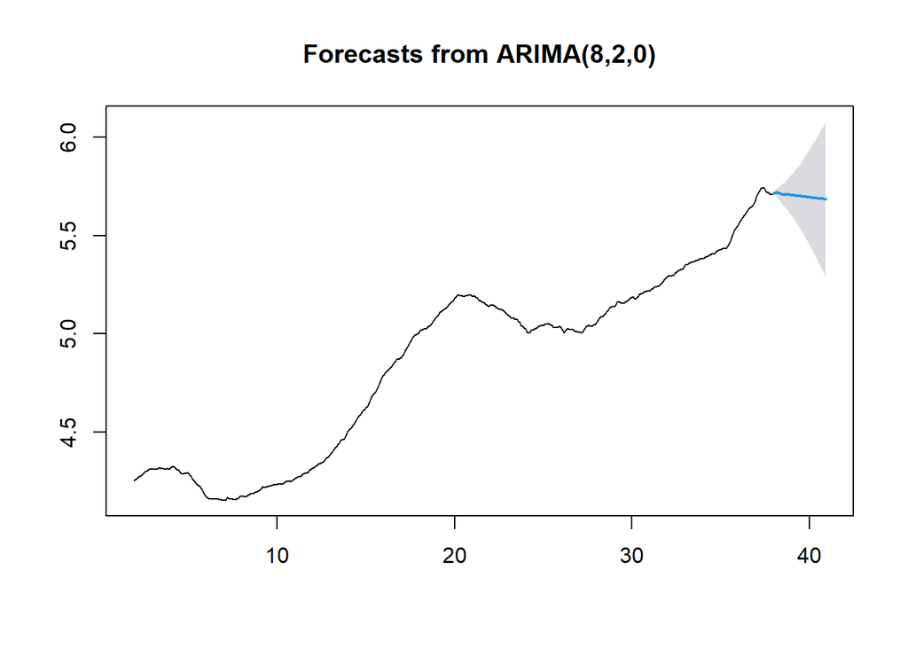

The plot here identifies that over a forecast that projects $\ln(BHPI)$ 36 time periods ahead, the data appears to trend slightly down over time. The shaded area around the indicates the 95% Confidence Interval of the potential values the forecast can take.

### Future Analysis

Form here, we wish to determine the appropriate number of lags necessary for future analysis. To determine the correct number of lags, the command `VARselect` prompts the data to determine the appropriate number of lags given a selection of identification criteria such as $AIC$, $BIC$, etc. The $AIC$ criterion will be used in this instance to determine the number of lags appropriate for the model.

```
## $selection
## AIC(n)  HQ(n)  SC(n) FPE(n)
##      7      7      7      7
##
## $criteria
##                    1             2             3             4             5
## AIC(n) -1.089002e+01 -1.090909e+01 -1.091039e+01 -1.097953e+01 -1.098047e+01
## HQ(n)  -1.088241e+01 -1.089768e+01 -1.089518e+01 -1.096052e+01 -1.095766e+01
## SC(n)  -1.087078e+01 -1.088023e+01 -1.087191e+01 -1.093144e+01 -1.092275e+01
## FPE(n)  1.864339e-05  1.829121e-05  1.826752e-05  1.704706e-05  1.703111e-05
##                    6             7             8             9            10
## AIC(n) -1.097584e+01 -1.101819e+01 -1.101550e+01 -1.101375e+01 -1.100903e+01
## HQ(n)  -1.094922e+01 -1.098777e+01 -1.098129e+01 -1.097573e+01 -1.096721e+01
## SC(n)  -1.090850e+01 -1.094123e+01 -1.092893e+01 -1.091756e+01 -1.090322e+01
## FPE(n)  1.711020e-05  1.640070e-05  1.644486e-05  1.647374e-05  1.655168e-05
##                   11            12
## AIC(n) -1.100492e+01 -1.100121e+01
## HQ(n)  -1.095930e+01 -1.095178e+01
## SC(n)  -1.088949e+01 -1.087615e+01
## FPE(n)  1.661994e-05  1.668191e-05
```

## Conclusion

Through a time-series approach to the data, we were successfully able to analyze how the BHPI has changed over the period of time in terms of their growth rates, first differences of the growth rates, and so forth. Multiple data visualizations showed the distribution of the variables and transformations were made to these variables in an attempt to normalize them. Numerous forms of Hypothesis Tests were conducted to explore relationships between the variables and their transformations, as well as to predict future values of these indexes and to forecast these values over a select timeframe.

It should be considered that this data is currently collected on a monthly basis and is ever-changing. New BHPIs values are being produced, and it is only a matter of time to really understand, predict accurately, and witness where the Boston, Massachusetts Housing Market is headed.